# Compare velociraptor results to results obtained directly with `scVelo`

Slightly modified from an extra vignette contained in the velociraptor package

Charlotte Soneson

April 26, 2022

# Load packages

```r
suppressPackageStartupMessages({
    library(scRNAseq)
    library(scuttle)
    library(scran)
    library(velociraptor)
    library(scater)
    library(cowplot)
    library(GGally)
    library(reticulate)
    library(SingleCellExperiment)
    library(basilisk)
    library(BiocStyle)
})
```

# Define virtual environment to use for reticulate

We will use the `velociraptor` conda environment in order to run the *scVelo* commands also directly in python.

```r
reticulate::use_condaenv(basilisk:::.obtainEnvironmentPath(velociraptor:::velo.env))
sys <- reticulate::import("sys")
sys$version
```

```
## [1] "3.7.7 (default, May  6 2020, 05:01:30) \n[Clang 4.0.1 (tags/RELEASE_401/final)]"
```

# Set temporary directory

Output objects (to move data from SCE to AnnData without using basilisk) will be saved to a temporary directory.

```r
tmpdir <- tempdir()
```

# Prepare data

We use an example data set from the *scRNAseq* package, and subset to the first 500 cells. The object is also saved to a `.h5ad` file for use with *scVelo* directly in python.

```r
## Load and subset data
sce <- scRNAseq::HermannSpermatogenesisData()[, 1:500]
```

```
## snapshotDate(): 2021-10-19
```

```
## see ?scRNAseq and browseVignettes('scRNAseq') for documentation
```

```
## loading from cache
```

```
## see ?scRNAseq and browseVignettes('scRNAseq') for documentation
```

```
## loading from cache
```

```
## see ?scRNAseq and browseVignettes('scRNAseq') for documentation
```

```
## loading from cache
```

```r
## Add 'counts' assay
assay(sce, "counts") <- assay(sce, "spliced")

## Save to h5ad file for python scVelo analysis
zellkonverter::writeH5AD(sce, X_name = "counts",
                         file = file.path(tmpdir, "anndata.h5ad"))
```

# Run analysis directly in python

We use the same conda environment as in `velociraptor` to run the *scVelo* analysis directly in python, rather than via the R wrapper.

## Steady-state model

```python
import scanpy as sc
import sys
import numpy as np
import anndata
import scvelo as scv
import matplotlib
import pandas as pd
from pathlib import Path
from os import path
adata=anndata.read(r.tmpdir + "/anndata.h5ad")
scv.pp.filter_and_normalize(adata, enforce=True, n_top_genes=2000)
```

```
## Normalized count data: X, spliced, unspliced.
## Exctracted 2000 highly variable genes.
## Logarithmized X.
```

```python
scv.pp.moments(adata)
```

```
## computing neighbors
##     finished (0:00:02) --> added
##     'distances' and 'connectivities', weighted adjacency matrices (adata.obsp)
## computing moments based on connectivities
##     finished (0:00:00) --> added
##     'Ms' and 'Mu', moments of un/spliced abundances (adata.layers)
```

```python
scv.tl.velocity(adata, mode="steady_state")
```

```
## computing velocities
##     finished (0:00:00) --> added
##     'velocity', velocity vectors for each individual cell (adata.layers)
```

```python
scv.tl.velocity_graph(adata)
```

```
## computing velocity graph
##
... 100%
    finished (0:00:00) --> added
##     'velocity_graph', sparse matrix with cosine correlations (adata.uns)
```

```python
scv.tl.velocity_pseudotime(adata)
```

```
## computing terminal states
## WARNING: Uncertain or fuzzy root cell identification. Please verify.
##     identified 1 region of root cells and 1 region of end points .
##     finished (0:00:00) --> added
##     'root_cells', root cells of Markov diffusion process (adata.obs)
##     'end_points', end points of Markov diffusion process (adata.obs)
```

```python
scv.tl.velocity_confidence(adata)
```

```
## --> added 'velocity_length' (adata.obs)
## --> added 'velocity_confidence' (adata.obs)
## --> added 'velocity_confidence_transition' (adata.obs)
```

```python
adata.write(r.tmpdir + "/anndata_withvelo_steadystate.h5ad")
```

## Dynamical model

```python
import scanpy as sc
import sys
import numpy as np
import anndata
import scvelo as scv
import matplotlib
import pandas as pd
adata=anndata.read(r.tmpdir + "/anndata.h5ad")
scv.pp.filter_and_normalize(adata, enforce=True, n_top_genes=2000)
```

```
## Normalized count data: X, spliced, unspliced.
## Exctracted 2000 highly variable genes.
## Logarithmized X.
```

```python
scv.pp.moments(adata)
```

```
## computing neighbors
##     finished (0:00:00) --> added
##     'distances' and 'connectivities', weighted adjacency matrices (adata.obsp)
## computing moments based on connectivities
##     finished (0:00:00) --> added
##     'Ms' and 'Mu', moments of un/spliced abundances (adata.layers)
```

```python
scv.tl.recover_dynamics(adata)
```

[output not shown]

```python
scv.tl.velocity(adata, mode="dynamical")
```

```
## computing velocities
##     finished (0:00:00) --> added
##     'velocity', velocity vectors for each individual cell (adata.layers)
```

```python
scv.tl.velocity_graph(adata)
```

```
## computing velocity graph
##
... 100%
    finished (0:00:00) --> added
##     'velocity_graph', sparse matrix with cosine correlations (adata.uns)
```

```python
scv.tl.velocity_pseudotime(adata)
```

```
## computing terminal states
##     identified 1 region of root cells and 1 region of end points .
##     finished (0:00:00) --> added
##     'root_cells', root cells of Markov diffusion process (adata.obs)
##     'end_points', end points of Markov diffusion process (adata.obs)
```

```python
scv.tl.latent_time(adata)
```

```
## computing latent time using root_cells as prior
##     finished (0:00:00) --> added
##     'latent_time', shared time (adata.obs)
```

```python
scv.tl.velocity_confidence(adata)
```

```
## --> added 'velocity_length' (adata.obs)
## --> added 'velocity_confidence' (adata.obs)
## --> added 'velocity_confidence_transition' (adata.obs)
```

```python
adata.write(r.tmpdir + "/anndata_withvelo_dynamical.h5ad")
```

## Read back objects in R for later comparison

```r
## Steady-state model, python
sceps <- zellkonverter::readH5AD(file.path(tmpdir, "anndata_withvelo_steadystate.h5ad"))

## Dynamical model, python
scepd <- zellkonverter::readH5AD(file.path(tmpdir, "anndata_withvelo_dynamical.h5ad"))
```

# Process the data set

Next, we apply some basic preprocessing to the data set - normalization, selection of highly variable genes, and dimension reduction.

```r
sce <- scuttle::logNormCounts(sce, assay.type=1)

## To use the HVGs determined by scVelo
# top.hvgs <- rownames(sceps)

## To get HVGs with scran
dec <- scran::modelGeneVar(sce)
top.hvgs <- scran::getTopHVGs(dec, n=2000)

set.seed(1)
sce <- scater::runPCA(sce, subset_row=top.hvgs)
sce <- scater::runTSNE(sce, dimred="PCA")
```

# Helper function

The function below runs scVelo via the R wrapper, first using the pre-normalized data and PCA from the SingleCellExperiment object, and then with `use_theirs=TRUE`. It also performs some comparisons between the two results.

```r
run_scv <- function(sce, top.hvgs, mode) {
    ## precomputed PCs and normalized values
    velo.out <- scvelo(
        sce, assay.X="counts", sf.X=sizeFactors(sce),
        subset.row=top.hvgs, use.dimred="PCA",
        mode=mode
    )
    stopifnot(colnames(sce) == colnames(velo.out))
    sce$velocity_pseudotime <- velo.out$velocity_pseudotime

    ## using scVelo normalization, gene selection and PCA calculation
    velo.out_theirs <- scvelo(
        sce, assay.X="counts", use.theirs=TRUE, mode=mode,
        scvelo.params=list(filter_and_normalize=list(enforce=TRUE,
                                                     n_top_genes=2000L))
    )
    stopifnot(colnames(sce) == colnames(velo.out_theirs))
    sce$velocity_pseudotime_theirs <- velo.out_theirs$velocity_pseudotime

    ## Inferred pseudotime
    print(cowplot::plot_grid(
        cowplot::plot_grid(
            plotTSNE(sce, colour_by="velocity_pseudotime"),
            plotTSNE(sce, colour_by="velocity_pseudotime_theirs"),
            nrow = 1),
        plotTSNE(sce, colour_by="celltype"), ncol = 1
    ))
    print(GGally::ggpairs(as.data.frame(colData(sce))[, c("velocity_pseudotime",
                                                          "velocity_pseudotime_theirs")]))

    shared_genes <- Reduce(intersect, list(rownames(velo.out), rownames(velo.out_theirs)))
    message("Number of shared genes:")
    print(length(shared_genes))
    message("Ours:")
    print(table(shared = rownames(velo.out) %in% shared_genes,
                velogene = rowData(velo.out)$velocity_genes))
    message("Theirs:")
    print(table(shared = rownames(velo.out_theirs) %in% shared_genes,
                velogene = rowData(velo.out_theirs)$velocity_genes))
    message("Among shared genes, how many are velocity genes:")
    print(table(ours = rowData(velo.out[shared_genes, ])$velocity_genes,
                theirs = rowData(velo.out_theirs[shared_genes, ])$velocity_genes))

    ## Correlations of velocities
    velo_corrs <- diag(cor(assay(velo.out[shared_genes, ], "velocity"),
                           assay(velo.out_theirs[shared_genes, colnames(velo.out)],
                                 "velocity"),
                           use = "pairwise.complete"))
    hist(velo_corrs, 100)

    ## Correlations of normalized spliced/unspliced values
    ms_corrs <- diag(cor(assay(velo.out[shared_genes, ], "Ms"),
                         assay(velo.out_theirs[shared_genes, colnames(velo.out)],
                               "Ms"),
                         use = "pairwise.complete"))
    hist(ms_corrs, 100)
    mu_corrs <- diag(cor(assay(velo.out[shared_genes, ], "Mu"),
                         assay(velo.out_theirs[shared_genes, colnames(velo.out)],
                               "Mu"),
                         use = "pairwise.complete"))
    hist(mu_corrs, 100)

    velo.out_theirs
}
```

# Run velociraptor and compare to python output

## Dynamical model

```r
sced <- run_scv(sce, top.hvgs=top.hvgs, mode="dynamical")
```

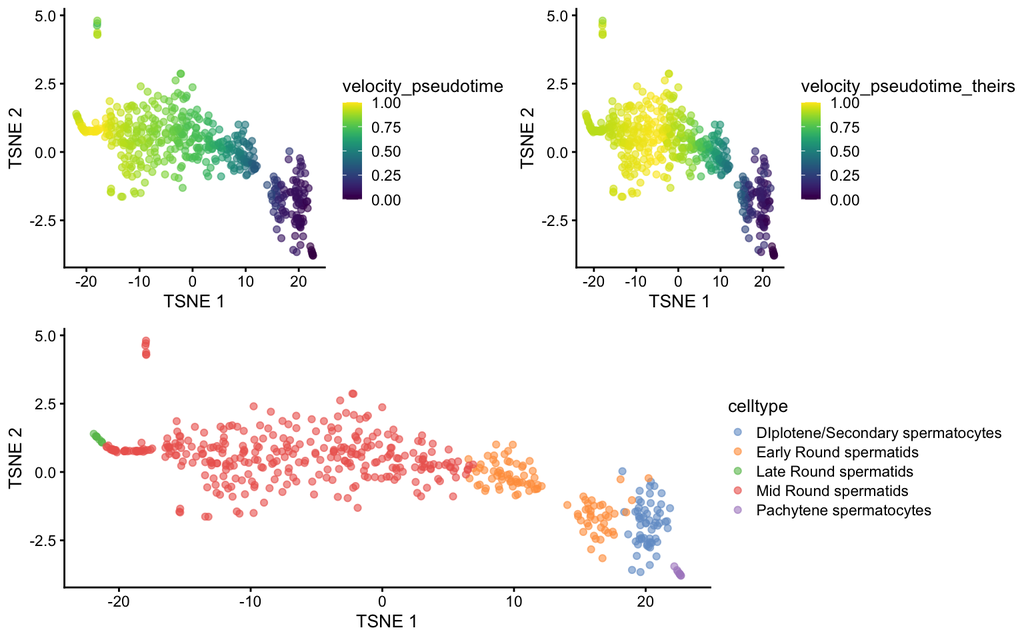

```
## Number of shared genes:
```

```
## [1] 1036
```

```
## Ours:
```

```
##        velogene
## shared  FALSE TRUE
##   FALSE   637  327
##   TRUE    720  316
```

```
## Theirs:
```

```
##        velogene
## shared  FALSE TRUE
##   FALSE   589  375
##   TRUE    739  297
```

```
## Among shared genes, how many are velocity genes:
```

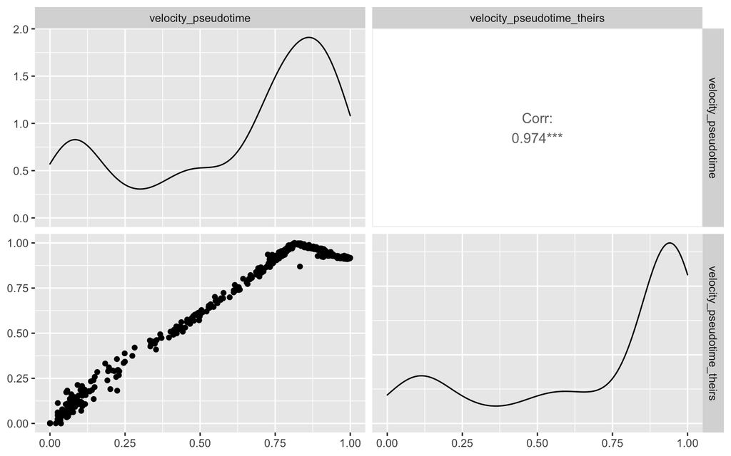

```
##        theirs
## ours    FALSE TRUE
##   FALSE   712    8
##   TRUE     27  289
```

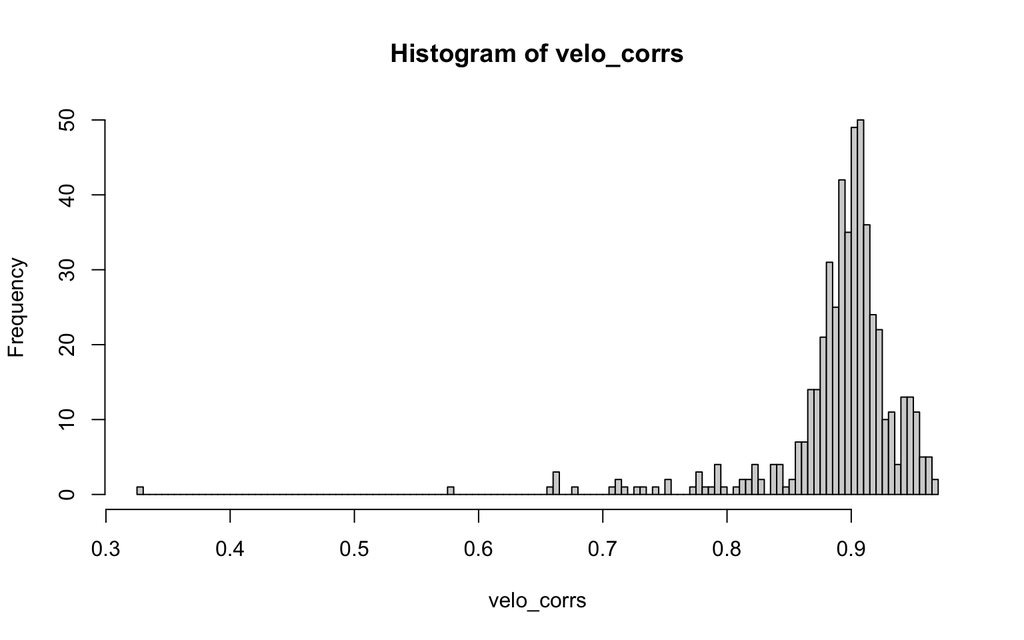

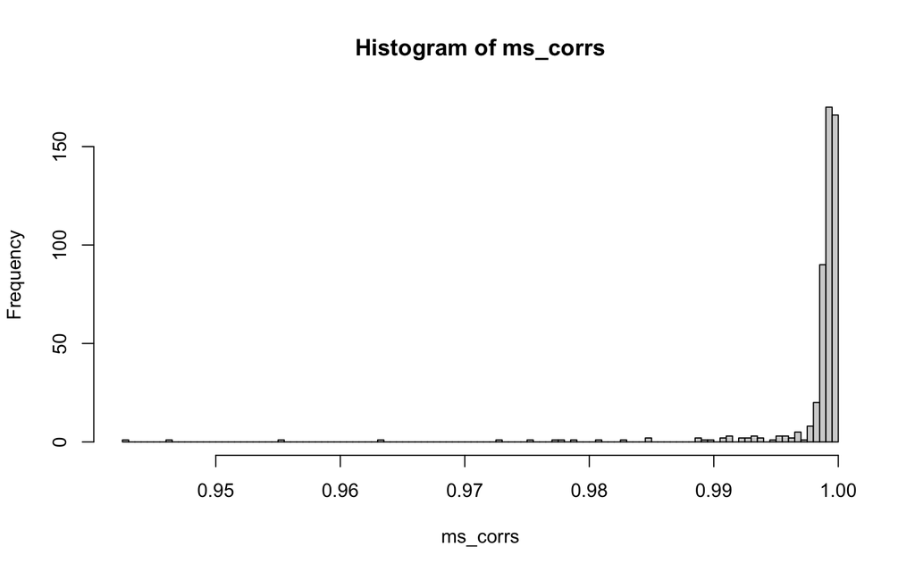

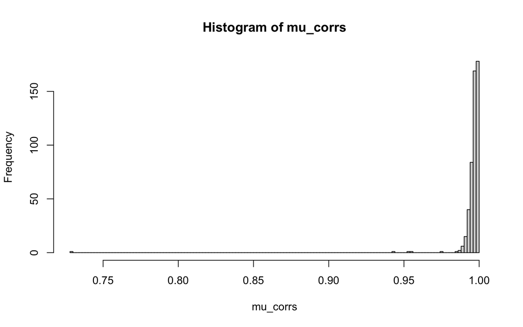

### Compare velociraptor run with ‘use_theirs=TRUE’ to direct python/scVelo calls

```r
stopifnot(all(colnames(sced) == colnames(scepd)),
          all(rownames(sced) == rownames(scepd)))
## Correlations of velocities
velo_corrs <- diag(cor(assay(sced, "velocity"),
                       assay(scepd, "velocity"),
                       use = "pairwise.complete"))
summary(velo_corrs)
```

```
##    Min. 1st Qu.  Median    Mean 3rd Qu.    Max.
##       1       1       1       1       1       1
```

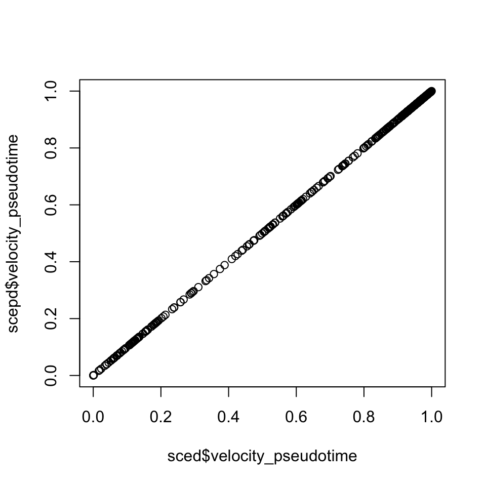

```r
plot(sced$velocity_pseudotime, scepd$velocity_pseudotime)
```

```r
summary(abs(sced$velocity_pseudotime - scepd$velocity_pseudotime))
```

```
##      Min.   1st Qu.    Median      Mean   3rd Qu.      Max.
## 0.000e+00 1.751e-07 5.364e-07 5.865e-07 1.013e-06 1.535e-06
```

```r
stopifnot(max(abs(sced$velocity_pseudotime - scepd$velocity_pseudotime)) < 1e-3)
```

## Steady-state model

```r
sces <- run_scv(sce, top.hvgs=top.hvgs, mode="steady_state")
```

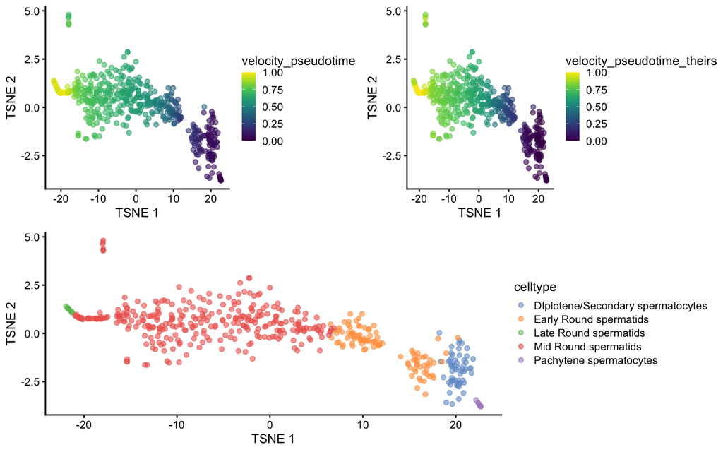

```
## Number of shared genes:
```

```
## [1] 1036
```

```
## Ours:
```

```
##        velogene
## shared  FALSE TRUE
##   FALSE   788  176
##   TRUE    741  295
```

```
## Theirs:
```

```
##        velogene
## shared  FALSE TRUE
##   FALSE   619  345
##   TRUE    750  286
```

```
## Among shared genes, how many are velocity genes:
```

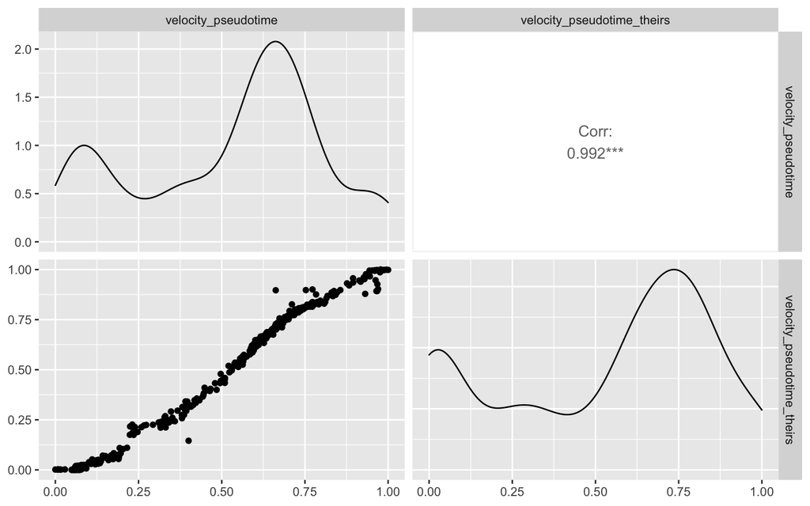

```
##        theirs
## ours    FALSE TRUE
##   FALSE   738    3
##   TRUE     12  283
```

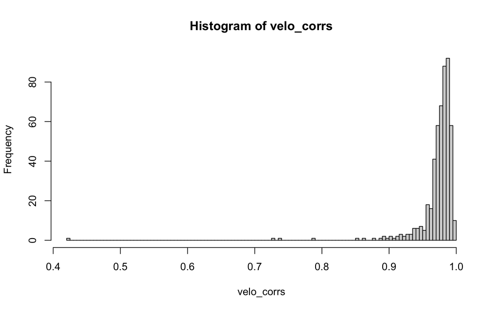

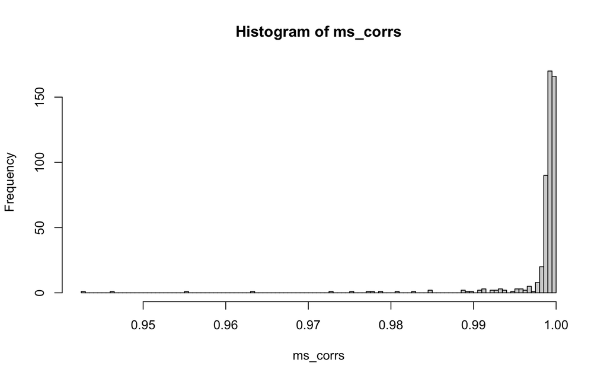

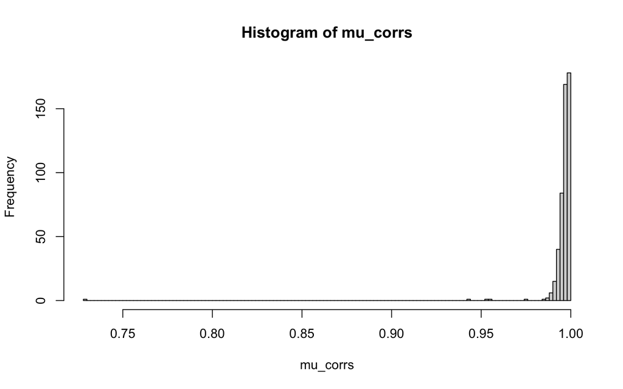

### Compare velociraptor run with ‘use_theirs=TRUE’ to direct python/scVelo calls

```r
stopifnot(all(colnames(sces) == colnames(sceps)),
          all(rownames(sces) == rownames(sceps)))
## Correlations of velocities
velo_corrs <- diag(cor(assay(sces, "velocity"),
                       assay(sceps, "velocity"),
                       use = "pairwise.complete"))
summary(velo_corrs)
```

```
##    Min. 1st Qu.  Median    Mean 3rd Qu.    Max.
##       1       1       1       1       1       1
```

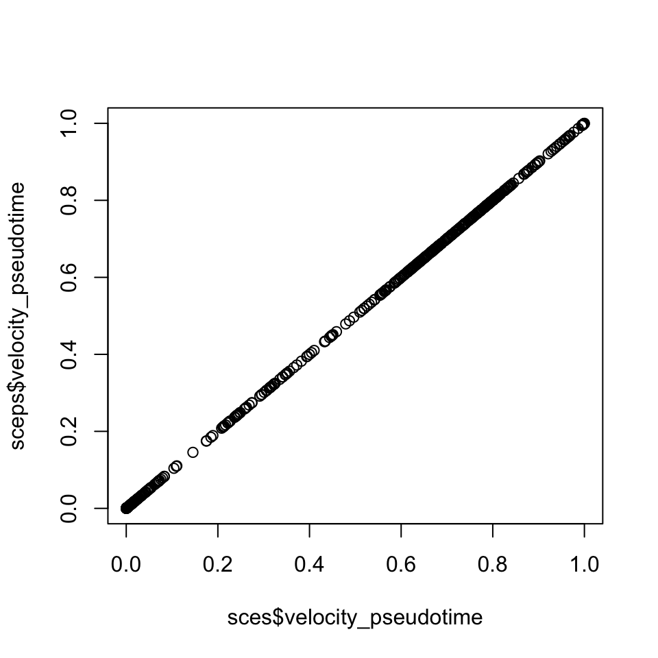

```r
plot(sces$velocity_pseudotime, sceps$velocity_pseudotime)
```

```r
summary(abs(sces$velocity_pseudotime - sceps$velocity_pseudotime))
```

```
##      Min.   1st Qu.    Median      Mean   3rd Qu.      Max.
## 0.000e+00 4.768e-07 2.049e-06 1.702e-06 2.742e-06 3.338e-06
```

```r
stopifnot(max(abs(sces$velocity_pseudotime - sceps$velocity_pseudotime)) < 1e-3)
```